# STA3050 Mid Sem Exam

Chesia Anyika

2024-06-19

**CASE SCENARIO: TOURIST ANALYSIS IN CAPETOWN**

Cape Town, a scenic destination celebrated for its breathtaking landscapes and rich cultural heritage, attracts a diverse group of tourists throughout the year. Its charming old town, scenic hiking trails, vibrant local markets, and tranquil beaches offer visitors a wide array of activities. The attached hypothetical data provides insights into the number of tourists visiting Cape Town from 2019 to 2023.

1. Determine the seasonal variation in tourist numbers for each using the ratio-to-moving average approach from 2019 to 2023. (6 Marks)

2. Obtain a clearer view of the underlying trend by eliminating seasonal fluctuations. (6 Marks)

3. Compute the long-term trend in tourist numbers over the specified period by applying the suitable trend analysis to the deseasonalized data. (6 Marks)

4. Obtain the cyclic index to better understand the cyclical variations in tourist numbers that may be influenced by economic cycles or other factors. (6 Marks)

5. Generate graphs of the data to illustrate the seasonal, trend, and cyclic components in the number of tourists visiting Cape Town. (6 Marks)

# 1. Data Preparation

First I imported all of the Libraries that would be necessary for my analysis.

```r
#libraries
library(readxl)
library(zoo)
library(tidyverse)
library(reshape2)
```

I then imported the data and examined it.

```r
#import the data
data <- read_excel("Mid-sem dataset.xlsx")

#view the dataset
data
```

```
## # A tibble: 60 × 4
##    Season Month      Year No_of_tourists
##    <chr>  <chr>     <dbl>          <dbl>
##  1 Summer January    2019          19500
##  2 Summer February   2019          21000
##  3 Autumn March      2019          23000
##  4 Autumn April      2019          25000
##  5 Autumn May        2019          27000
##  6 Winter June       2019          30000
##  7 Winter July       2019          32000
##  8 Winter August     2019          31000
##  9 Spring September  2019          29000
## 10 Spring October    2019          27000
## # ℹ 50 more rows
```

I ensured the Month column is a factor variable with defined order

```r
# Define the chronological order of the months
month_levels <- c("January", "February", "March", "April", "May", "June", "July", "August", "September", "October", "November", "December")

# Convert the Month variable to a factor with the defined order
data$Month <- factor(data$Month, levels = month_levels, ordered = TRUE)
```

I then Merged the Month and year columns for ease of plotting.

```r
#combine the two columns
data$Month_Year <- paste(data$Month, data$Year, sep = "_")

#convert into factor variable
data$Month_Year <- factor(data$Month_Year, levels = data$Month_Year)

#view results
data$Month_Year
```

```
##  [1] January_2019   February_2019  March_2019     April_2019     May_2019
##  [6] June_2019      July_2019      August_2019    September_2019 October_2019
## [11] November_2019  December_2019  January_2020   February_2020  March_2020
## [16] April_2020     May_2020       June_2020      July_2020      August_2020
## [21] September_2020 October_2020   November_2020  December_2020  January_2021
## [26] February_2021  March_2021     April_2021     May_2021       June_2021
## [31] July_2021      August_2021    September_2021 October_2021   November_2021
## [36] December_2021  January_2022   February_2022  March_2022     April_2022
## [41] May_2022       June_2022      July_2022      August_2022    September_2022
## [46] October_2022   November_2022  December_2022  January_2023   February_2023
## [51] March_2023     April_2023     May_2023       June_2023      July_2023
## [56] August_2023    September_2023 October_2023   November_2023  December_2023
## 60 Levels: January_2019 February_2019 March_2019 April_2019 ... December_2023
```

# 2. Seasonal Variation

The **seasonal variation** refers to fluctuations or changes in a phenomenon that occur regularly at specific times within a year. The seasonal variation can be assumed to be the difference between the actual value and the moving average trend value. Seasonal variations can be calculated using the additive or multiplicative models.

First, we can compute the moving average values using the **Ratio to moving average method**

## 2.1 Moving Average

First I computed a 12 point moving average as follows:

```r
#12 moving average
data$moving_avg =  rollapply(data$No_of_tourists, width = 12, FUN = mean, align = 'center', fill = NA)

#view reuslts
data$moving_avg
```

```
##  [1]       NA       NA       NA       NA       NA 26041.67 26250.00 26500.00
##  [9] 26750.00 27000.00 27250.00 27416.67 27583.33 27750.00 27916.67 28083.33
## [17] 28250.00 28416.67 28625.00 28875.00 29125.00 29375.00 29625.00 29875.00
## [25] 30125.00 30375.00 30625.00 30875.00 31125.00 31375.00 31833.33 32250.00
## [33] 32666.67 33083.33 33500.00 33916.67 34333.33 34750.00 35166.67 35583.33
## [41] 36000.00 36416.67 36833.33 37250.00 37666.67 38083.33 38500.00 38333.33
## [49] 38333.33 38250.00 38083.33 37833.33 37583.33 37333.33       NA       NA
## [57]       NA       NA       NA       NA
```

I then computed the 2 point centered moving average as follows:

```r
# Calculate the centered moving average
data$centered_moving_avg <- rollapply(data$moving_avg, width = 2, FUN = mean, align = 'center', fill = NA)

#view results
data$centered_moving_avg
```

```
##  [1]       NA       NA       NA       NA       NA 26145.83 26375.00 26625.00
##  [9] 26875.00 27125.00 27333.33 27500.00 27666.67 27833.33 28000.00 28166.67
## [17] 28333.33 28520.83 28750.00 29000.00 29250.00 29500.00 29750.00 30000.00
## [25] 30250.00 30500.00 30750.00 31000.00 31250.00 31604.17 32041.67 32458.33
## [33] 32875.00 33291.67 33708.33 34125.00 34541.67 34958.33 35375.00 35791.67
## [41] 36208.33 36625.00 37041.67 37458.33 37875.00 38291.67 38416.67 38333.33
## [49] 38291.67 38166.67 37958.33 37708.33 37458.33       NA       NA       NA
## [57]       NA       NA       NA       NA
```

## 2.2 Seasonal Variation

Using the multiplicative model to calculate the seasonal variation, I computed the **quotient of the actual value by centered moving average value**.

```r
#compute seasonal variation
data$seasonal_variation <- data$No_of_tourists/data$centered_moving_avg

#view results
head(data$seasonal_variation, 10)
```

```
##  [1]        NA        NA        NA        NA        NA 1.1474104 1.2132701
##  [8] 1.1643192 1.0790698 0.9953917
```

I visualised the seasonal variation using a line graph as follows:

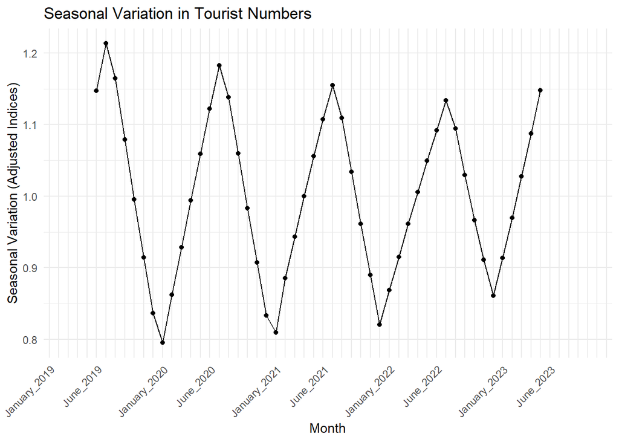

```r
# Create the plot using ggplot2 with adjusted x-axis labels
ggplot(data, aes(x = Month_Year)) +
  geom_line(aes(y = seasonal_variation, group = 1), linetype = "solid") +
  geom_point(aes(y = seasonal_variation, group = 1)) +
  labs(title = "Seasonal Variation in Tourist Numbers",
       x = "Month",
       y = "Seasonal Variation (Adjusted Indices)") +
  theme_minimal() +
  theme(axis.text.x = element_text(angle = 45, hjust = 1)) +
  scale_x_discrete(labels = function(x) {
    ifelse(grepl("^January|^June", x), x, "")
  })
```

This graph shows a cyclical trend in the monthly variations, with tourist number routinely being lowest at the beginning of the year, and highest towards the middle of the year.

# 3. De-seasonalisation

De-seasonalization, also known as seasonal adjustment or seasonal decomposition, is a statistical process used to remove the seasonal variations or fluctuations from a time series dataset. The goal of deseasonalizing data is to isolate the underlying trend or irregular components, thereby allowing for more accurate analysis, forecasting, or comparison across different time periods.

In order to compute the deseasonalised values given the centered moving average, we must compute the **seasonal ratio,** and the **seasonal indices**.

## 3.1 Seasonal Ratio

I computed the seasonal ratio for each period for which we have the moving average) by dividing each actual time series value by its corresponding moving average value as per the formula:

$$\text{Seasonal Ratio} = \frac{\text{Actual Value}}{\text{Moving
Average}} \times 100$$

```r
#compute the seasonal ratios
data$seasonal_ratio <- (data$No_of_tourists / data$centered_moving_avg)*100

#view results
data$seasonal_ratio
```

```
##  [1]        NA        NA        NA        NA        NA 114.74104 121.32701
##  [8] 116.43192 107.90698  99.53917  91.46341  83.63636  79.51807  86.22754
## [15]  92.85714  99.40828 105.88235 112.19869 118.26087 113.79310 105.98291
## [22]  98.30508  90.75630  83.33333  80.99174  88.52459  94.30894 100.00000
## [29] 105.60000 110.74489 115.47464 110.91142 103.42205  96.12015  88.99876
## [36]  82.05128  86.85163  91.53754  96.11307 100.58207 104.94822 109.21502
## [43] 113.38583 109.45495 102.97030  96.62677  91.10629  86.08696  91.40370
## [50]  96.94323 102.74424 108.72928 114.79422        NA        NA        NA
## [57]        NA        NA        NA        NA
```

I then created a two-way table with Months as row-names, Years as column-names and seasonal ratios as the values.

```r
# Create a two-way table
seasonal_table <- dcast(data, Month ~ Year, value.var = "seasonal_ratio")

# Set proper column names
names(seasonal_table) <- c("Month", paste0("Year_", names(seasonal_table)[2:ncol(seasonal_table)]))

#view results
seasonal_table
```

```
##        Month Year_2019 Year_2020 Year_2021 Year_2022 Year_2023
## 1    January        NA  79.51807  80.99174  86.85163  91.40370
## 2   February        NA  86.22754  88.52459  91.53754  96.94323
## 3      March        NA  92.85714  94.30894  96.11307 102.74424
## 4      April        NA  99.40828 100.00000 100.58207 108.72928
## 5        May        NA 105.88235 105.60000 104.94822 114.79422
## 6       June 114.74104 112.19869 110.74489 109.21502        NA
## 7       July 121.32701 118.26087 115.47464 113.38583        NA
## 8     August 116.43192 113.79310 110.91142 109.45495        NA
## 9  September 107.90698 105.98291 103.42205 102.97030        NA
## 10   October  99.53917  98.30508  96.12015  96.62677        NA
## 11  November  91.46341  90.75630  88.99876  91.10629        NA
## 12  December  83.63636  83.33333  82.05128  86.08696        NA
```

## 3.2 Seasonal Indices

I then computed the **Seasonal Indices** which are the row-wise median, and added it to the seasonal table as follows:

```r
# Calculate the row-wise median
row_medians <- apply(seasonal_table[, -1], 1, function(x) median(x, na.rm = TRUE))

# Add the row-wise medians to the table
seasonal_table$row_median <- row_medians

# view table column
seasonal_table[ncol(seasonal_table)]
```

```
##    row_median
## 1    83.92168
## 2    90.03107
## 3    95.21101
## 4   100.29104
## 5   105.74118
## 6   111.47179
## 7   116.86776
## 8   112.35226
## 9   104.70248
## 10   97.46593
## 11   90.93130
## 12   83.48485
```

I then computed the **Adjusted Seasonal Indices** as per the formula:

$$\text{Adjusted Seasonal index} = \frac{\text{Seasonal Index}}{\text{Avg.
Seasonal Index}} \times 100$$

```r
#compute average seasonal index
Avg.seasonal_index <- ((sum(seasonal_table$row_median))/nrow(seasonal_table))

#view result
cat('Average Seasonal Index: ', Avg.seasonal_index)
```

```
## Average Seasonal Index:  99.37269
```

```r
#compute adjusted seasonal index
seasonal_table$Adj.seasonal_index <- ((seasonal_table$row_median)/(Avg.seasonal_index))*100

#view results
seasonal_table[ncol(seasonal_table)]
```

```
##    Adj.seasonal_index
## 1            84.45145
## 2            90.59940
## 3            95.81204
## 4           100.92414
## 5           106.40868
## 6           112.17547
## 7           117.60550
## 8           113.06151
## 9           105.36343
## 10           98.08120
## 11           91.50531
## 12           84.01186
```

I then computed the **sum** and **average** of the Adjusted moving indices, which should sum up to $1200$ and $100$ respectively.

```r
#compute sum and average
Adj.sum <- sum(seasonal_table$Adj.seasonal_index)
Adj.avg <- (Adj.sum)/nrow(seasonal_table)

#view
cat('Sum: ', Adj.sum,
    'Average: ', Adj.avg)
```

```
## Sum:  1200 Average:  100
```

## 3.3 De-seasonalised Data

With the Adjusted Seasonal Indices, we can now compute the de-seasonalised values of the tourist numbers per month. For calculating deseasonalised values, we divide the actual value by its corresponding seasonal index, that is:

$$\text{Deseasonalised value} = \frac{\text{Actual Value}}{\text{Seasonal
Index}} \times 100$$

```r
#add seasonal indices to data table
data$Adj.seasonal_index <- rep(seasonal_table$Adj.seasonal_index, nrow(data)/12)

#view results
data[ncol(data)]
```

```
## # A tibble: 60 × 1
##    Adj.seasonal_index
##                 <dbl>
##  1               84.5
##  2               90.6
##  3               95.8
##  4              101.
##  5              106.
##  6              112.
##  7              118.
##  8              113.
##  9              105.
## 10               98.1
## # ℹ 50 more rows
```

```r
#compute deseasonalised values
data$deseasonalised <- ((data$No_of_tourists)/(data$Adj.seasonal_index))*100

#view results
data$deseasonalised
```

```
##  [1] 23090.19 23178.96 24005.33 24771.08 25373.87 26743.81 27209.61 27418.70
##  [9] 27523.78 27528.21 27320.82 27377.09 26050.47 26490.24 27136.46 27743.61
## [17] 28193.19 28526.74 28910.21 29187.65 29421.97 29567.34 29506.48 29757.70
## [25] 29010.75 29801.52 30267.59 30716.14 31012.51 31201.12 31461.11 31841.08
## [33] 32269.26 32626.03 32784.98 33328.63 35523.37 35320.32 35486.14 35670.36
## [41] 35711.37 35658.42 35712.61 36263.45 37014.74 37723.85 38249.14 39280.17
## [49] 41443.93 40839.12 40704.70 40624.57 40410.24 33875.50 35712.61 35378.97
## [57] 35116.55 34665.16 34970.65 35709.24
```

## 3.4 De-seasonalised Seasonal variation

I then computed the seasonal variation of the deseasonalised data to compare the observed trend with the previous values.

### 3.4.1 Moving average

```r
#12 moving average
data$moving_avg2 =  rollapply(data$deseasonalised, width = 12, FUN = mean, align = 'center', fill = NA)

#view reuslts
data$moving_avg2
```

```
##  [1]       NA       NA       NA       NA       NA 25961.79 26208.48 26484.42
##  [9] 26745.35 26993.06 27228.00 27376.58 27518.29 27665.71 27823.89 27993.82
## [17] 28175.95 28374.34 28621.03 28896.97 29157.90 29405.61 29640.55 29863.42
## [25] 30075.99 30297.11 30534.38 30789.27 31062.48 31360.06 31902.78 32362.68
## [33] 32797.56 33210.41 33601.98 33973.42 34327.71 34696.25 35091.70 35516.52
## [41] 35971.87 36467.83 36961.21 37421.11 37855.99 38268.84 38660.41 38511.83
## [49] 38511.83 38438.13 38279.95 38025.05 37751.85 37454.27       NA       NA
## [57]       NA       NA       NA       NA
```

```r
# Calculate the centered moving average
data$centered_moving_avg2 <- rollapply(data$moving_avg2, width = 2, FUN = mean, align = 'center', fill = NA)

#view results
data$centered_moving_avg2
```

```
##  [1]       NA       NA       NA       NA       NA 26085.13 26346.45 26614.88
##  [9] 26869.20 27110.53 27302.29 27447.44 27592.00 27744.80 27908.85 28084.89
## [17] 28275.15 28497.68 28759.00 29027.43 29281.75 29523.08 29751.98 29969.70
## [25] 30186.55 30415.75 30661.83 30925.88 31211.27 31631.42 32132.73 32580.12
## [33] 33003.98 33406.19 33787.70 34150.57 34511.98 34893.97 35304.11 35744.19
## [41] 36219.85 36714.52 37191.16 37638.55 38062.41 38464.63 38586.12 38511.83
## [49] 38474.98 38359.04 38152.50 37888.45 37603.06       NA       NA       NA
## [57]       NA       NA       NA       NA
```

### 3.4.2 Seasonal Variation

```r
#compute seasonal variation
data$seasonal_variation2 <- data$deseasonalised/data$centered_moving_avg2

#view results
head(data$seasonal_variation2, 10)
```

```
##  [1]       NA       NA       NA       NA       NA 1.025251 1.032762 1.030202
##  [9] 1.024362 1.015407
```

### 3.4.3 Visualisation

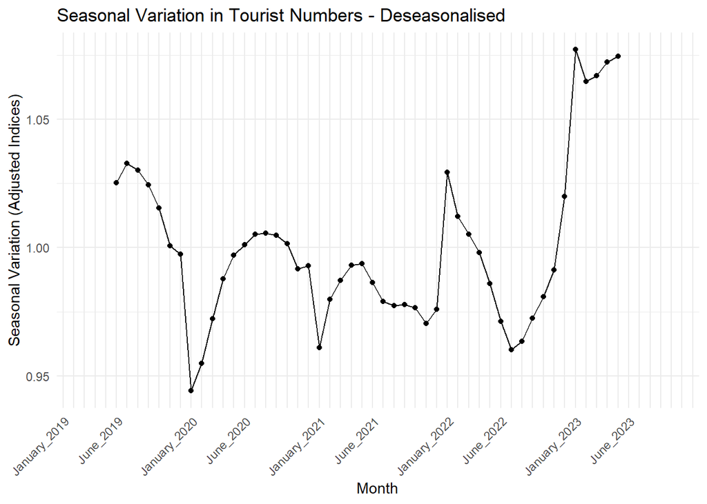

```r
# Create the plot using ggplot2 with adjusted x-axis labels
ggplot(data, aes(x = Month_Year)) +
  geom_line(aes(y = seasonal_variation2, group = 1), linetype = "solid") +
  geom_point(aes(y = seasonal_variation2, group = 1)) +
  labs(title = "Seasonal Variation in Tourist Numbers - Deseasonalised",
       x = "Month",
       y = "Seasonal Variation (Adjusted Indices)") +
  theme_minimal() +
  theme(axis.text.x = element_text(angle = 45, hjust = 1)) +
  scale_x_discrete(labels = function(x) {
    ifelse(grepl("^January|^June", x), x, "")
  })
```

# 4. Trend Analysis

We can use **Normal Equations** to estimate the constants of a **linear and quadratic model**, and thus fit both linear and quadratic tends to the deseasonalised data.

The Normal Equations are a set of simultaneous linear equations derived from the least squares criterion, used to estimate the parameters $\beta_0$ (intercept), $\beta_1$ (slope), and $\beta_2$ (quadratic term) in the case of linear and quadratic regression models.

## 4.1 Linear Trend

For a Linear Regression Model $Y_t = \beta_0 + \beta_1t$, the normal equations are:

$$\sum Y_t = n \beta_0 + \beta_1 \sum t\\\sum tY_t = \beta_0 \sum t +
\beta_1 \sum t^2$$

> Where:

> $\beta_0$ is the intercept, the predicted value of Y when t = 0.

> $\beta_1$ is the slope of the trend line.

For ease of calculation, we take the following transformations in t:

$$X_t =\begin{cases}\frac{t - middle\ value}{interval \ in \ t \ values}
& \text{when n is odd}\\\frac{t - average\ of\ two \ middle\
values}{half\ of \ interval \ in \ t \ values} & \text{when n is
even}\end{cases}$$

I defined this as a function as follows:

```r
#create function to compute Xt
compute_Xt <- function(t) {
  n <- length(t)
  interval <- diff(range(t)) / (n - 1)

  if (n %% 2 == 1) {
    middle_value <- median(t)
    X_t <- (t - middle_value) / interval
  } else {
    middle_values <- sort(t)[c(n / 2, n / 2 + 1)]
    middle_value_avg <- mean(middle_values)
    half_interval <- interval / 2
    X_t <- (t - middle_value_avg) / half_interval
  }

  return(X_t)
}
```

We then get the transformed equations as follows:

$$\sum Y_t = n \beta_0 + \beta_1 \sum X_t\\
\sum X_tY_t = \beta_0 \sum X_t + \beta_1 \sum X_t^2$$

With these equations, using `Month` as $t$ and `deseasonalised` as $Y_t$ we need to compute $\sum Y_t$, $\sum X_t$, $\sum X_tY_t$ and $\sum X_t^2$. I thus created these respective columns in the data table as follows:

**Since `Month` is a non-numeric column, I replaced it with a sequence of numebrs.

```r
#replace month variable with a sequence
data$t <- seq(1, nrow(data))

#compute the Xt column
data$Xt <- compute_Xt(data$t)

#compute XtYt
data$XtYt <- (data$Xt)*(data$deseasonalised)

#compute Xt^2
data$Xt.sq <- (data$Xt)^2

#View results
data[15:18]
```

```
## # A tibble: 60 × 4
##        t    Xt      XtYt Xt.sq
##    <int> <dbl>     <dbl> <dbl>
##  1     1   -59 -1362321.  3481
##  2     2   -57 -1321201.  3249
##  3     3   -55 -1320293.  3025
##  4     4   -53 -1312867.  2809
##  5     5   -51 -1294067.  2601
##  6     6   -49 -1310447.  2401
##  7     7   -47 -1278852.  2209
##  8     8   -45 -1233842.  2025
##  9     9   -43 -1183523.  1849
## 10    10   -41 -1128657.  1681
## # ℹ 50 more rows
```

I then computed the sums of the respective columns

```r
#compute sums of relevant columns
Yt.sum <- sum(data$deseasonalised)
Xt.sum <- sum(data$Xt)
XtYt.sum <- sum(data$XtYt)
Xtsq.sum <- sum(data$Xt.sq)
n <- nrow(data)

#View sums
cat('\n Sum of Yt: ', Yt.sum, '\n Sum of Xt: ', Xt.sum, '\n Sum of XtYt: ',XtYt.sum, '\n Sum of Xt.sq: ',Xtsq.sum, '\n n: ', n)
```

```
##
##  Sum of Yt:  1915419
##  Sum of Xt:  0
##  Sum of XtYt:  9170928
##  Sum of Xt.sq:  71980
##  n:  60
```

I used these computed values to solve for $\beta_0$ and $\beta_1$ using the normal equations, and obtained the following:

$$1915419 = 60 \beta_0 + 0 \beta_1 \\9170928 = 0 \beta_0 + 71980 \beta_1$$

I used the `solve()` function to compute this as follows:

```r
# Define the coefficients matrix
A <- matrix(c(60, 0, 0, 71980), nrow = 2, byrow = TRUE)

# Define the constants vector
b <- c(1915419, 9170928)

# Solve for beta
beta <- solve(A, b)

# Display the solutions
beta_0 <- beta[1]
beta_1 <- beta[2]

cat("beta_0 =", beta_0, "\n")
```

```
## beta_0 = 31923.65
```

```r
cat("beta_1 =", beta_1, "\n")
```

```
## beta_1 = 127.4094
```

To transform this to be in terms of t, I defined two functions that compute the parameters for the $X_t$ function in the case that $n$ is even, as per the formula:

$$X_t[n\ is\ even] = \frac{t - avg\ of\ middle\ values}{half\ interval\ in
\ t \ values}$$

```r
# Function to compute average of the middle values
compute_middle_value_avg <- function(t) {
  n <- length(t)

  if (n %% 2 == 1) {
    middle_value_avg <- median(t)
  } else {
    middle_values <- sort(t)[c(n / 2, n / 2 + 1)]
    middle_value_avg <- mean(middle_values)
  }

  return(middle_value_avg)
}

# Function to compute half the interval between the middle values
compute_half_interval <- function(t) {
  n <- length(t)
  interval <- diff(range(t)) / (n - 1)

  if (n %% 2 == 0) {
    half_interval <- interval / 2
  } else {
    half_interval <- NA
  }

  return(half_interval)
}
```

I computed the parameters as follows:

```r
#compute parameters
mid <- compute_middle_value_avg(data$t)
interval <- compute_half_interval(data$t)

#view results
cat('\n Average of Middle Values: ', mid, '\n Half Interval of middle Values: ', interval)
```

```
##
##  Average of Middle Values:  30.5
##  Half Interval of middle Values:  0.5
```

Thus my $X_t$ function is:

$$X_t = \frac{t-30.5}{0.5}$$

I computed this for each row entry and added the values as a column in the data- frame.

```r
#compute estimated values
data$Yt.hat <- beta_0 + (beta_1*((data$t)-mid)/interval)

#View results
data[ncol(data)]
```

```
## # A tibble: 60 × 1
##    Yt.hat
##     <dbl>
##  1 24406.
##  2 24661.
##  3 24916.
##  4 25171.
##  5 25426.
##  6 25681.
##  7 25935.
##  8 26190.
##  9 26445.
## 10 26700.
## # ℹ 50 more rows
```

## 4.2 Quadratic Trend

For a Quadratic Regression Model $Y_t = \beta_0 + \beta_1t + \beta_2t^2$, the normal equations are:

$$\sum Y_t = n \beta_0 + \beta_1 \sum t + \beta_2 \sum t^2 \\\sum t Y_t =
\beta_0 \sum t + \beta_1 \sum t^2 + \beta_2 \sum t^3 \\\sum t^2 Y_t =
\beta_0 \sum t^2 + \beta_1 \sum t^3 + \beta_2 \sum t^4$$

For ease of computation, we may take the following transformations in t:

$$X_t =\begin{cases}\frac{t - middle\ value}{interval \ in \ t \ values}
& \text{when n is odd}\\\frac{t - average\ of\ two \ middle\
values}{half\ of \ interval \ in \ t \ values} & \text{when n is
even}\end{cases}$$

I defined this function in R as compute_Xtin the previous section. Thus we get the following transformed normal equations:

$$\sum Y_t = n \beta_0 + \beta_1 \sum Xt + \beta_2 \sum X^2_t \\\sum X_t
Y_t = \beta_0 \sum X_t + \beta_1 \sum X_t^2 + \beta_2 \sum X_t^3 \\\sum
X_t^2 Y_t = \beta_0 \sum X_t^2 + \beta_1 \sum X_t^3 + \beta_2 \sum
X_t^4\\$$

With these equations, taking `t` as $t$ and `deseasonalised` as $Y_t$, we need to compute $\sum Yt$, $\sum Xt$, $\sum X_tY_t$, $\sum X_t^2$, $\sum X_t^2Y_t$, $\sum X_t^3$ and $\sum X_t^4$.

As the first four parameters in the above list were previously calculated when computing the linear trend, I computed the remaining 3 parameters and created their respective tables in the data table as follows:

```r
#compute Xt.sqYt
data$Xt.sqYt <- (data$Xt.sq)*(data$deseasonalised)

#compute Xt.cube
data$Xt.cube <- (data$Xt)^3

#compute Xt.four
data$Xt.four <- (data$Xt)^4

#view the data results
data[20:22]
```

```
## # A tibble: 60 × 3
##      Xt.sqYt Xt.cube  Xt.four
##        <dbl>   <dbl>    <dbl>
##  1 80376949. -205379 12117361
##  2 75308443. -185193 10556001
##  3 72616132. -166375  9150625
##  4 69581966. -148877  7890481
##  5 65997433. -132651  6765201
##  6 64211899. -117649  5764801
##  7 60106031. -103823  4879681
##  8 55522876.  -91125  4100625
##  9 50891471.  -79507  3418801
## 10 46274925.  -68921  2825761
## # ℹ 50 more rows
```

I then computed the sum of the parameters:

```r
#compute Xt.sqYt
Xt.sqYt.sum <- sum(data$Xt.sqYt)

#compute Xt.cube
Xt.cube.sum <- sum(data$Xt.cube)

#compute Xt.four
Xt.four.sum <- sum(data$Xt.four)

#view the results
cat('\n Sum of Xt.sqYt: ', Xt.sqYt.sum, '\n Sum of Xt.cube: ', Xt.cube.sum, '\n Sum of Xt.four: ', Xt.four.sum )
```

```
##
##  Sum of Xt.sqYt:  2261225353
##  Sum of Xt.cube:  0
##  Sum of Xt.four:  155376028
```

I used these computed values to solve for $\beta_0$, $\beta_1$ and $\beta_2$ in the normal equations, as follows:

$$1915419 = 60\beta_0 + 0\beta_1 + 71980 \beta_2 \\
9170928 = 0\beta_0 + 71980\beta_1 + 0\beta_2\\
2261225353
= 71980\beta_0 + 0\beta_1 +
155376028
\beta_2$$

I solved these simultaneous equations using the matrix method, by rearranging them into the following system of matrices:

$$\begin{pmatrix}
60 & 0 & 71980 \\
0 & 71980 & 0 \\
71980 & 0 & 155376028
\end{pmatrix}
\begin{pmatrix}
\beta_0 \\
\beta_1 \\
\beta_2
\end{pmatrix} =
\begin{pmatrix}
1915419 \\
9170928 \\
2261225353
\end{pmatrix}$$

I used the `solve()` function to solve these as follows:

```r
# Define the coefficients matrix
A <- matrix(c(60, 0,71980, 0, 71980, 0, 71980, 0, 155376028), nrow = 3, byrow = TRUE)

# Define the constants vector
b <- c(1915419, 9170928, 2261225353)

# Solve for beta
beta <- solve(A, b)

# Display the solutions
beta_0 <- beta[1]
beta_1 <- beta[2]
beta_2 <- beta[3]

cat("beta_0 =", beta_0, "\n")
```

```
## beta_0 = 32560.45
```

```r
cat("beta_1 =", beta_1, "\n")
```

```
## beta_1 = 127.4094
```

```r
cat("beta_2 =", beta_2, "\n")
```

```
## beta_2 = -0.5308148
```

I then input $\beta_0$, $\beta_1$ and $\beta_2$ into the estimator equation $\hat Y_t = \beta_0 + \beta_1 X_t + \beta_2 X_t^2$, to get:

$$\hat Y_t = 32560.45 + 127.4094 X_t
-0.5308 X_t^2$$

Thus the final estimator equation can be written as follows:

$$\hat Y_t = 32560.45 + 127.4094
(\frac{t - 30.5}{0.5}) -0.5308 (\frac{t - 30.5}{0.5})^2$$

I computed this for each row entry, and added the results to a new column in the `data` table

```r
#compute the equation
data$Yt.hat2 <- beta_0 + (beta_1*(data$t - mid)/interval) + (beta_2*((data$t - mid)/interval)^2)

#view the results
data[ncol(data)]
```

```
## # A tibble: 60 × 1
##    Yt.hat2
##      <dbl>
##  1  23196.
##  2  23573.
##  3  23947.
##  4  24317.
##  5  24682.
##  6  25043.
##  7  25400.
##  8  25752.
##  9  26100.
## 10  26444.
## # ℹ 50 more rows
```

## 4.3 Visual Plot of Trend Lines

**Line Graph: Linear and Quadratic Trends**

I used a combined **line graph** to visually compare the computed linear and quadratic trend lines with the original values. I used the `geom_line()` function in the `ggplot` library.

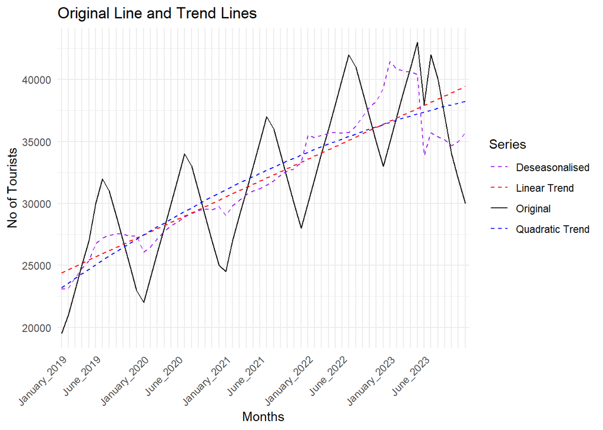

```r
# Plot original and forecasted values
ggplot(data, aes(x = Month_Year)) +
  geom_line(aes(y = No_of_tourists, color = "Original", group = 1), linetype = "solid") +
  geom_line(aes(y = deseasonalised, color = "Deseasonalised", group = 1), linetype = "dashed")+
  geom_line(aes(y = Yt.hat, color = "Linear Trend", group = 1), linetype = "dashed") +
  geom_line(aes(y = Yt.hat2, color = "Quadratic Trend", group = 1), linetype = "dashed") +
  labs(title = "Original Line and Trend Lines",
       x = "Months",
       y = "No of Tourists",
       color = "Series") +
  scale_color_manual(values = c("Original" = "black",
                                "Deseasonalised" = "purple",
                                 "Linear Trend" = "red",
                                 "Quadratic Trend" = "blue")) +
  theme_minimal()+
  theme(axis.text.x = element_text(angle = 45, hjust = 1)) +
  scale_x_discrete(labels = function(x) {
    ifelse(grepl("^January|^June", x), x, "")
  })
```

**Interpretation**

From just this visualisation, it is difficult to determine which trend line fits the data the best, Thus we can compare **forecast errors** to better determine this.

## 4.4 Forecast Errors

**Forecast errors** can further help us determine which trend line more accurately represents the original values by measuring the **deviation between predicted and actual outcomes**. Smaller errors indicate a more precise fit, allowing for better evaluation and comparison of different models.

The formula for computing forecast errors is:

$$E_t = Y_t - \hat Y_t$$

I computed this formula for both the linear and quadratic trends, and inputted the values into new columns on the `data` table as shown below:

```r
#compute forecast errors for linear trend
data$lin.err <- (data$deseasonalised)-(data$Yt.hat)

#compute forecast errors for quadratic trend
data$quad.err <- (data$deseasonalised)-(data$Yt.hat2)

#view the results
data[24:25]
```

```
## # A tibble: 60 × 2
##    lin.err quad.err
##      <dbl>    <dbl>
##  1 -1316.    -105.
##  2 -1482.    -395.
##  3  -911.      58.1
##  4  -400.     454.
##  5   -51.9    692.
##  6  1063.    1701.
##  7  1274.    1810.
##  8  1228.    1667.
##  9  1079.    1423.
## 10   828.    1084.
## # ℹ 50 more rows
```

I then created a line plot comparison of the forecast errors for the linear and quadratic trends.

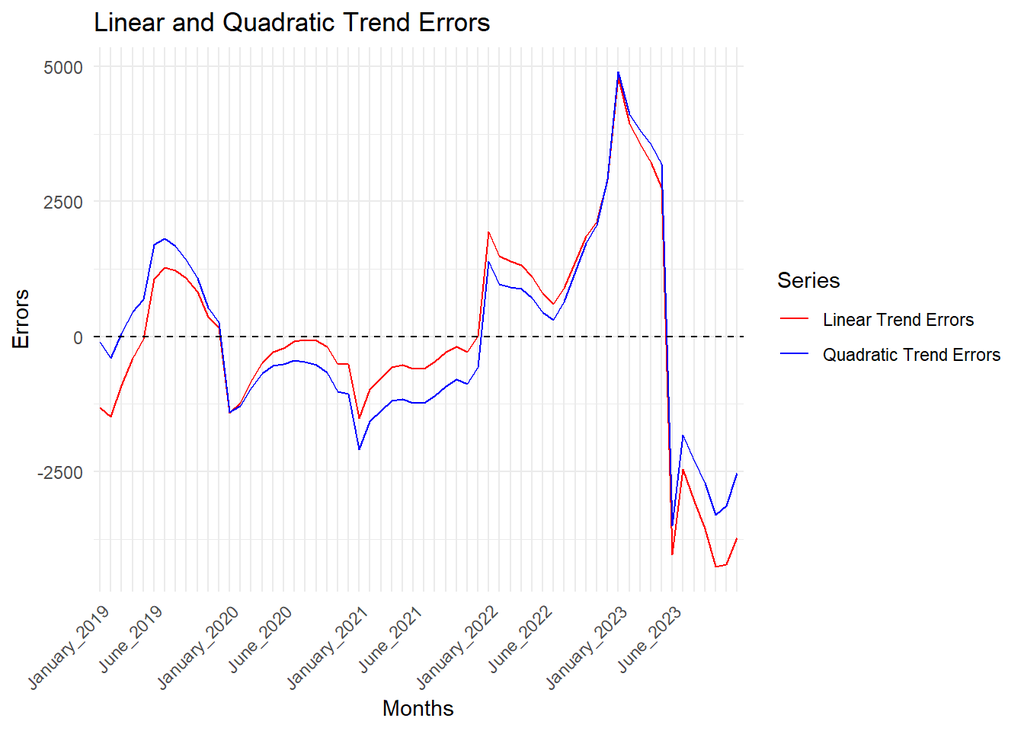

```r
# Plot original and forecasted values
ggplot(data, aes(x = Month_Year)) +
  geom_line(aes(y = lin.err, color = "Linear Trend Errors", group = 1), linetype = "solid") +
  geom_line(aes(y = quad.err, color = "Quadratic Trend Errors", group = 1), linetype = "solid") +
  geom_hline(yintercept = 0, linetype = "dashed", color = "black") +
  labs(title = "Linear and Quadratic Trend Errors",
       x = "Months",
       y = "Errors",
       color = "Series") +
  scale_color_manual(values = c("Linear Trend Errors" = "red",
                                 "Quadratic Trend Errors" = "blue")) +
  theme_minimal()+
  theme(axis.text.x = element_text(angle = 45, hjust = 1)) +
  scale_x_discrete(labels = function(x) {
    ifelse(grepl("^January|^June", x), x, "")
  })
```

**Interpretation**

# 5. Cyclic Components

A cycle in the time series means a business cycle which normally exceeds a year in length. It has four phases; **prosperity (boom), recession, depression and recovery**. I used the **Residual Method** to compute the cyclic components of the data as follows:

## 5.1 Compute Cyclic Components

As we have already computed the **deseasonalised values** and **linear trend line values**, we can compute the cyclic components as per the formula:

$$\text{Cyclic Component} = \frac{\text{Deseasonalised Value}}{\text{Trend
Value}} \times 100$$

This computes the deseasonalised values as a percentage of the trend values. I did this as follows:

```r
#compute cyclic components
data$cyclic <- ((data$deseasonalised)/(data$Yt.hat))*100

#View result
data[ncol(data)]
```

```
## # A tibble: 60 × 1
##    cyclic
##     <dbl>
##  1   94.6
##  2   94.0
##  3   96.3
##  4   98.4
##  5   99.8
##  6  104.
##  7  105.
##  8  105.
##  9  104.
## 10  103.
## # ℹ 50 more rows
```

## 5.2 Visualisation

I then visualised the trend of the cyclic values as follows:

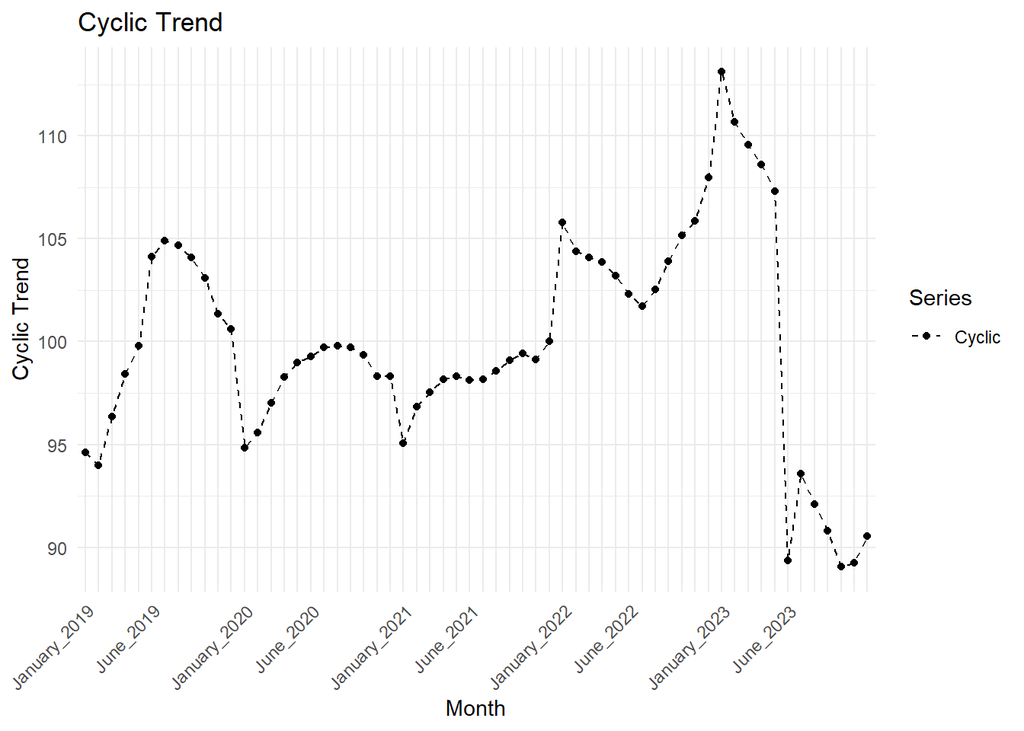

```r
# Create the plot using ggplot2 with adjusted x-axis labels
ggplot(data, aes(x = Month_Year)) +
  geom_line(aes(y = cyclic, color = 'Cyclic', group = 1), linetype = "dashed") +
  geom_point(aes(y = cyclic, color = 'Cyclic', group = 1)) +
  labs(title = "Cyclic Trend",
       x = "Month",
       y = "Cyclic Trend",
       color = 'Series') +
  scale_color_manual(values = c("Cyclic" = 'black')) +
  theme_minimal() +
  theme(axis.text.x = element_text(angle = 45, hjust = 1)) +
  scale_x_discrete(labels = function(x) {
    ifelse(grepl("^January|^June", x), x, "")
  })
```